# Reproducible Research Course Project 1

## Analysing Activity Data

1. Code for reading in the dataset and/or processing the data

```r
activity <- read.csv("activity.csv")
dim(activity)
```

```
## [1] 17568     3
```

```r
head(activity)
```

```
##   steps       date interval
## 1    NA 2012-10-01        0
## 2    NA 2012-10-01        5
## 3    NA 2012-10-01       10
## 4    NA 2012-10-01       15
## 5    NA 2012-10-01       20
## 6    NA 2012-10-01       25
```

```r
summary(activity)
```

```
##      steps                date          interval
##  Min.   :  0.00   2012-10-01:  288   Min.   :   0.0
##  1st Qu.:  0.00   2012-10-02:  288   1st Qu.: 588.8
##  Median :  0.00   2012-10-03:  288   Median :1177.5
##  Mean   : 37.38   2012-10-04:  288   Mean   :1177.5
##  3rd Qu.: 12.00   2012-10-05:  288   3rd Qu.:1766.2
##  Max.   :806.00   2012-10-06:  288   Max.   :2355.0
##  NA's   :2304     (Other)   :15840
```

2. Histogram of the total number of steps taken each day

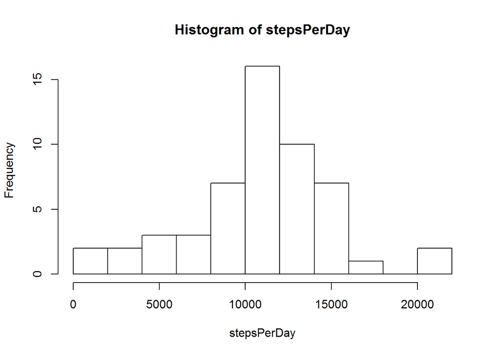

```r
stepsPerDay <- tapply(activity$steps, activity$date, sum)
hist(stepsPerDay, breaks = 10)
```

3. Mean and median number of steps taken each day

```r
summary(stepsPerDay)
```

```
##    Min. 1st Qu.  Median    Mean 3rd Qu.    Max.    NA's
##      41    8841   10760   10770   13290   21190       8
```

4. Time series plot of the average number of steps taken

```r
meanIntervalSteps <- tapply(activity$steps, activity$interval, mean, na.rm = TRUE)
summary(meanIntervalSteps)
```

```
##    Min. 1st Qu.  Median    Mean 3rd Qu.    Max.
##   0.000   2.486  34.110  37.380  52.830 206.200
```

```r
head(meanIntervalSteps)
```

```
##         0         5        10        15        20        25
## 1.7169811 0.3396226 0.1320755 0.1509434 0.0754717 2.0943396
```

```r
str(meanIntervalSteps)
```

```
##  num [1:288(1d)] 1.717 0.3396 0.1321 0.1509 0.0755 ...
##  - attr(*, "dimnames")=List of 1
##   ..$ : chr [1:288] "0" "5" "10" "15" ...
```

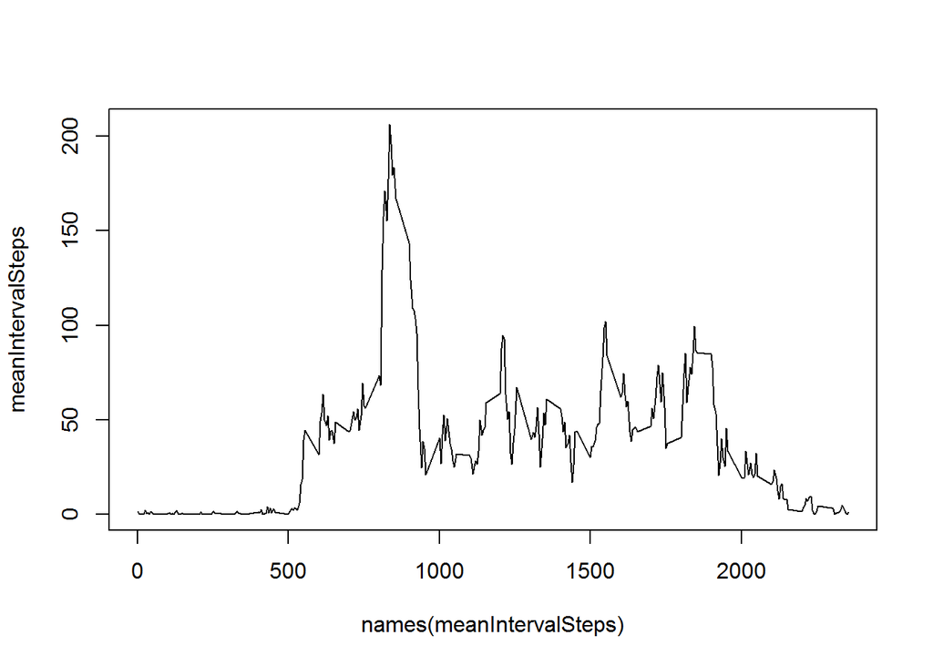

```r
plot(names(meanIntervalSteps),meanIntervalSteps, type = "l")
```

5. The 5-minute interval that, on average, contains the maximum number of steps

```r
names(meanIntervalSteps)[which.max(meanIntervalSteps)]
```

```
## [1] "835"
```

6. Code to describe and show a strategy for imputing missing data
   - Check how many rows with missing data exist
   - Missing values will be impute according to mean value of corresponding interval
   - Creating imputed data in a new column

```r
sum(is.na(activity$steps))
```

```
## [1] 2304
```

```r
activity$steps_imp <- ifelse(is.na(activity$steps), meanIntervalSteps[as.character(activity$interval)], activity$steps)
```

7. Histogram of the total number of steps taken each day after missing values are imputed

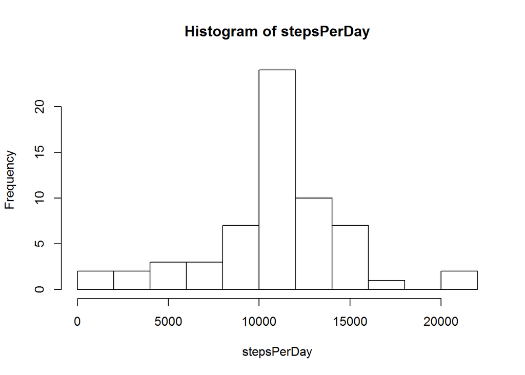

```r
stepsPerDay <- tapply(activity$steps_imp, activity$date, sum)
hist(stepsPerDay, breaks = 10)
```

```r
summary(stepsPerDay)
```

```
##    Min. 1st Qu.  Median    Mean 3rd Qu.    Max.
##      41    9819   10770   10770   12810   21190
```

It seems that the imputation did not affect the mean (as expected),  
but it caused the median to rise and become equal to the mean.

8. Panel plot comparing the average number of steps taken per 5-minute interval across weekdays and weekends

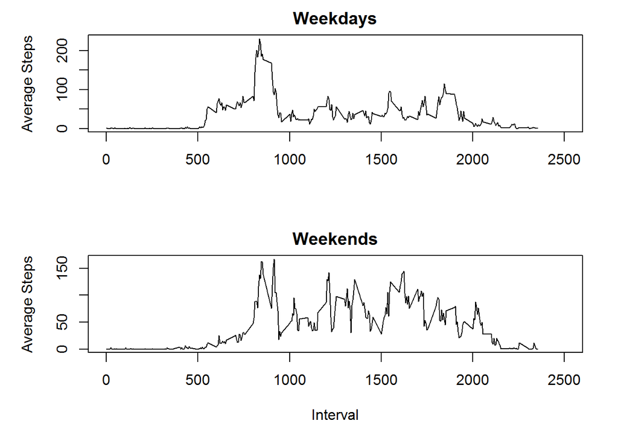

```r
activity$weekday <- as.numeric(format(as.Date(activity$date),"%w"))
activity$is.weekend <- ifelse(activity$weekday == 6 | activity$weekday == 0, 1, 0)
wdActivity <- subset(activity, is.weekend == 0)
wdActivityIM <- tapply(wdActivity$steps_imp, wdActivity$interval, mean)
weActivity <- subset(activity, is.weekend == 1)
weActivityIM <- tapply(weActivity$steps_imp, weActivity$interval, mean)
par(mfrow = c(2,1), mar = c(5,5,2,2))
plot(names(wdActivityIM),wdActivityIM, type = "l", main = "Weekdays", xlab = "" , ylab = "Average Steps",xlim = c(0,2500))
plot(names(weActivityIM),weActivityIM, type = "l", main = "Weekends", xlab = "Interval", ylab = "Average Steps",xlim = c(0,2500))
```

End of Project 1